# Ford GoBike Dataset

## by Ahmed Maged Mohammed

## Asking Questions

### **Q1** Does the frequency of trips depend on if a user is a Male, Female or Other?

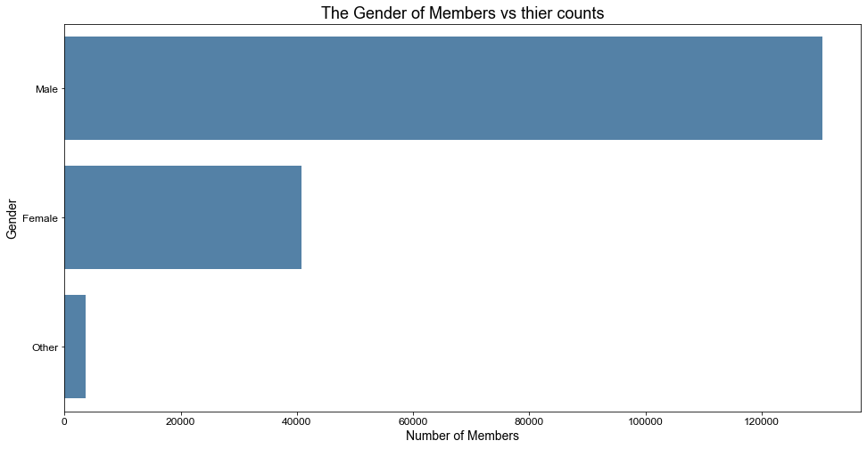

> From this first plot we can see that Males in general use the Ford GoBike service approximately 3 times as Females and orders of magnitudes more than Other, the marketing department should focus more on Females to increase their numbers.

### **Q2** How long does the average trip take?

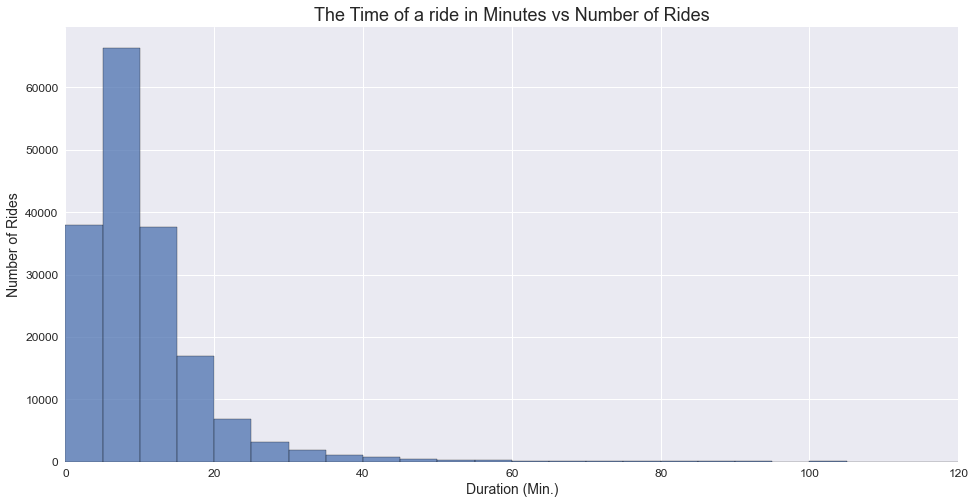

> From this graph we can see that the average ride time is around 5 to 10 minutes which means that the majority of users approximately 65000 take 5 to 10 min trips while a smaller number of users (approx. 39000) take the bikes for 5 minutes and a simillar number take the bike for more than 10 minutes, and a minority of users take the bikes for more than an hour.

### **Q3** Does the frequency of trips depend on the age of the user?

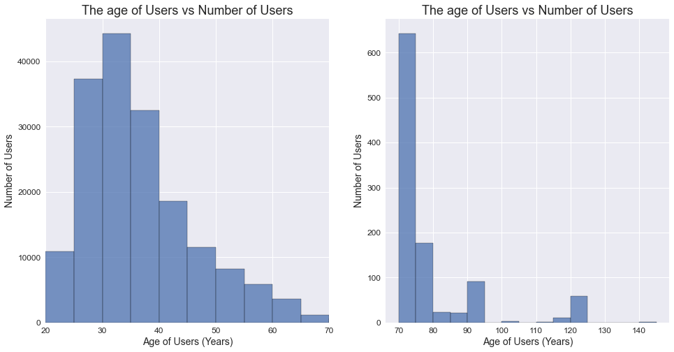

> From the graph we can observe that most of the users are between the age of 25 to 40 and decreasing after 40 till we reach a few users by the age of 80.

### **Q4** Does the frequency of trips depend on if a user is a subscriber or customer?

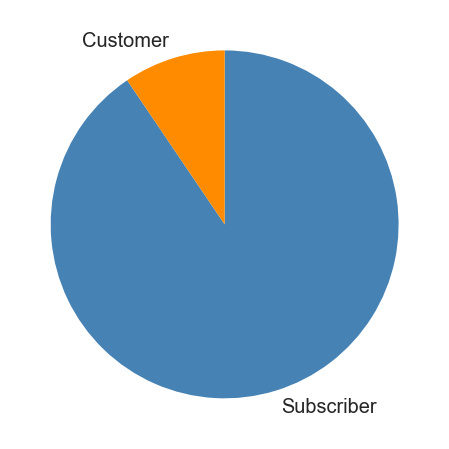